# Feature Engineering 데이터 확인 및 전처리

```python
import pandas as pd
#data=pd.read_csv('./mini_project/cs_data.csv')
data=pd.read_csv('./cs_data.csv')
#data=pd.read_csv('./Program_Files/mini_project/cs_data.csv')
```

```python
data.drop(columns='Unnamed: 0', inplace=True)
data
```

|  | SeriousDlqin2yrs | RevolvingUtilizationOfUnsecuredLines | age | NumberOfTime30-59DaysPastDueNotWorse | DebtRatio | MonthlyIncome | NumberOfOpenCreditLinesAndLoans | NumberOfTimes90DaysLate | NumberRealEstateLoansOrLines | NumberOfTime60-89DaysPastDueNotWorse | NumberOfDependents |
| --- | --- | --- | --- | --- | --- | --- | --- | --- | --- | --- | --- |
| 0 | 1 | 0.766127 | 45 | 2 | 0.802982 | 9120.0 | 13 | 0 | 6 | 0 | 2.0 |
| 1 | 0 | 0.957151 | 40 | 0 | 0.121876 | 2600.0 | 4 | 0 | 0 | 0 | 1.0 |
| 2 | 0 | 0.658180 | 38 | 1 | 0.085113 | 3042.0 | 2 | 1 | 0 | 0 | 0.0 |
| 3 | 0 | 0.233810 | 30 | 0 | 0.036050 | 3300.0 | 5 | 0 | 0 | 0 | 0.0 |
| 4 | 0 | 0.907239 | 49 | 1 | 0.024926 | 63588.0 | 7 | 0 | 1 | 0 | 0.0 |
| ... | ... | ... | ... | ... | ... | ... | ... | ... | ... | ... | ... |
| 149995 | 0 | 0.040674 | 74 | 0 | 0.225131 | 2100.0 | 4 | 0 | 1 | 0 | 0.0 |
| 149996 | 0 | 0.299745 | 44 | 0 | 0.716562 | 5584.0 | 4 | 0 | 1 | 0 | 2.0 |
| 149997 | 0 | 0.246044 | 58 | 0 | 3870.000000 | NaN | 18 | 0 | 1 | 0 | 0.0 |
| 149998 | 0 | 0.000000 | 30 | 0 | 0.000000 | 5716.0 | 4 | 0 | 0 | 0 | 0.0 |
| 149999 | 0 | 0.850283 | 64 | 0 | 0.249908 | 8158.0 | 8 | 0 | 2 | 0 | 0.0 |

150000 rows × 11 columns

## 데이터 확인

```python
data.info()
```

```
<class 'pandas.core.frame.DataFrame'>
RangeIndex: 150000 entries, 0 to 149999
Data columns (total 11 columns):
 #   Column                                Non-Null Count   Dtype
---  ------                                --------------   -----
 0   SeriousDlqin2yrs                      150000 non-null  int64
 1   RevolvingUtilizationOfUnsecuredLines  150000 non-null  float64
 2   age                                   150000 non-null  int64
 3   NumberOfTime30-59DaysPastDueNotWorse  150000 non-null  int64
 4   DebtRatio                             150000 non-null  float64
 5   MonthlyIncome                         120269 non-null  float64
 6   NumberOfOpenCreditLinesAndLoans       150000 non-null  int64
 7   NumberOfTimes90DaysLate               150000 non-null  int64
 8   NumberRealEstateLoansOrLines          150000 non-null  int64
 9   NumberOfTime60-89DaysPastDueNotWorse  150000 non-null  int64
 10  NumberOfDependents                    146076 non-null  float64
dtypes: float64(4), int64(7)
memory usage: 12.6 MB
```

```python
#기초 통계량 확인
data.describe()

#전체적으로 이상치 분포되어 있음.
```

|  | SeriousDlqin2yrs | RevolvingUtilizationOfUnsecuredLines | age | NumberOfTime30-59DaysPastDueNotWorse | DebtRatio | MonthlyIncome | NumberOfOpenCreditLinesAndLoans | NumberOfTimes90DaysLate | NumberRealEstateLoansOrLines | NumberOfTime60-89DaysPastDueNotWorse | NumberOfDependents |
| --- | --- | --- | --- | --- | --- | --- | --- | --- | --- | --- | --- |
| count | 150000.000000 | 150000.000000 | 150000.000000 | 150000.000000 | 150000.000000 | 1.202690e+05 | 150000.000000 | 150000.000000 | 150000.000000 | 150000.000000 | 146076.000000 |
| mean | 0.066840 | 6.048438 | 52.295207 | 0.421033 | 353.005076 | 6.670221e+03 | 8.452760 | 0.265973 | 1.018240 | 0.240387 | 0.757222 |
| std | 0.249746 | 249.755371 | 14.771866 | 4.192781 | 2037.818523 | 1.438467e+04 | 5.145951 | 4.169304 | 1.129771 | 4.155179 | 1.115086 |
| min | 0.000000 | 0.000000 | 0.000000 | 0.000000 | 0.000000 | 0.000000e+00 | 0.000000 | 0.000000 | 0.000000 | 0.000000 | 0.000000 |
| 25% | 0.000000 | 0.029867 | 41.000000 | 0.000000 | 0.175074 | 3.400000e+03 | 5.000000 | 0.000000 | 0.000000 | 0.000000 | 0.000000 |
| 50% | 0.000000 | 0.154181 | 52.000000 | 0.000000 | 0.366508 | 5.400000e+03 | 8.000000 | 0.000000 | 1.000000 | 0.000000 | 0.000000 |
| 75% | 0.000000 | 0.559046 | 63.000000 | 0.000000 | 0.868254 | 8.249000e+03 | 11.000000 | 0.000000 | 2.000000 | 0.000000 | 1.000000 |
| max | 1.000000 | 50708.000000 | 109.000000 | 98.000000 | 329664.000000 | 3.008750e+06 | 58.000000 | 98.000000 | 54.000000 | 98.000000 | 20.000000 |

## 결측치 처리

```python
#결측지 확인
data.isna().sum()
```

```
SeriousDlqin2yrs                            0
RevolvingUtilizationOfUnsecuredLines        0
age                                         0
NumberOfTime30-59DaysPastDueNotWorse        0
DebtRatio                                   0
MonthlyIncome                           29731
NumberOfOpenCreditLinesAndLoans             0
NumberOfTimes90DaysLate                     0
NumberRealEstateLoansOrLines                0
NumberOfTime60-89DaysPastDueNotWorse        0
NumberOfDependents                       3924
dtype: int64
```

```python
#결측치 버리기
drop_data=data.dropna()
```

```python
#결측치 처리
#평균값으로 대체
#각 특성 열의 전체 평균으로 누락된 값 대체
import numpy as np
from sklearn.impute import SimpleImputer
#data.fillna(data.mean())

imr = SimpleImputer(missing_values=np.nan, strategy='mean')
imr = imr.fit(data.values)
imputed_data = imr.transform(data.values)
```

```python
#각 열별 최빈값으로 변경하는 것은 사용하지 않겠음
#mode()
"""
참고
# Null 값을 mode로 대체하는 코드 예제
freq_values = df_ms.documentposition.value_counts().index[0]
df['col1'] = df['col1'].fillna(freq_values)
"""
for i in range(len(data.columns)):
    freq_values=data.iloc[:,i].mode()
    data.iloc[:,i]=data.iloc[:,i].fillna(freq_values)
```

## (재확인) 이상치 처리

1. 그 값을 그대로 유지한다.
2. 결측치 처리를 한다.
3. 다른 값으로 대체한다.
   - 보통 그 값이 가질 수 있는 Min/Max값을 설정한 뒤 그 값으로 변경한다.

```python
#이상치 처리
#1분위수 이하 3분위수 이상인 이상치 제거
quatile_1 = data.quantile(0.25)
quatile_3 = data.quantile(0.75)
IQR = quatile_3-quatile_1
condition = (data < (quatile_1 - 1.5 * IQR)) | (data > (quatile_3 + 1.5*IQR))
#any() : 하나라도 True인게 있으면 True / axis=1 이면 열 기준
condition = condition.any(axis=1)
#팬시 인덱싱
search_df = data[condition]
IQR_data = pd.DataFrame(search_df)
IQR_data

#본인은 이상치를 이대로 유지하겠음
```

|  | SeriousDlqin2yrs | RevolvingUtilizationOfUnsecuredLines | age | NumberOfTime30-59DaysPastDueNotWorse | DebtRatio | MonthlyIncome | NumberOfOpenCreditLinesAndLoans | NumberOfTimes90DaysLate | NumberRealEstateLoansOrLines | NumberOfTime60-89DaysPastDueNotWorse | NumberOfDependents |
| --- | --- | --- | --- | --- | --- | --- | --- | --- | --- | --- | --- |
| 0 | 1 | 0.766127 | 45 | 2 | 0.802982 | 9120.0 | 13 | 0 | 6 | 0 | 2.0 |
| 2 | 0 | 0.658180 | 38 | 1 | 0.085113 | 3042.0 | 2 | 1 | 0 | 0 | 0.0 |
| 4 | 0 | 0.907239 | 49 | 1 | 0.024926 | 63588.0 | 7 | 0 | 1 | 0 | 0.0 |
| 6 | 0 | 0.305682 | 57 | 0 | 5710.000000 | NaN | 8 | 0 | 3 | 0 | 0.0 |
| 8 | 0 | 0.116951 | 27 | 0 | 46.000000 | NaN | 2 | 0 | 0 | 0 | NaN |
| ... | ... | ... | ... | ... | ... | ... | ... | ... | ... | ... | ... |
| 149987 | 0 | 1.000000 | 28 | 0 | 0.055692 | 3249.0 | 3 | 1 | 0 | 0 | 0.0 |
| 149988 | 0 | 0.902051 | 31 | 1 | 0.347924 | 7515.0 | 10 | 0 | 1 | 0 | 0.0 |
| 149989 | 0 | 0.013356 | 62 | 0 | 0.001408 | 9233.0 | 4 | 0 | 0 | 0 | 3.0 |
| 149992 | 0 | 0.871976 | 50 | 0 | 4132.000000 | NaN | 11 | 0 | 1 | 0 | 3.0 |
| 149997 | 0 | 0.246044 | 58 | 0 | 3870.000000 | NaN | 18 | 0 | 1 | 0 | 0.0 |

73146 rows × 11 columns

## Feature Selection

```python
#랜덤 포레스트를 이용한 특성 중요도
from sklearn.ensemble import RandomForestClassifier

y=drop_data['SeriousDlqin2yrs']
feat_labels = drop_data.drop(['SeriousDlqin2yrs'], axis =1)

rf = RandomForestClassifier(n_estimators=500,
                            n_jobs=-1,
                            random_state=0)

from sklearn.model_selection import train_test_split
X_train, X_test, y_train, y_test = train_test_split(feat_labels, y, stratify=y, random_state=0)

rf.fit(X_train, y_train)
importances = rf.feature_importances_

#argsort 작은값부터 순서대로 데이터의 위치 반환
indices = np.argsort(importances)[::-1]
```

```python
importances
#indices[0]
#feat_labels.columns[0]
```

```
array([0.18943532, 0.12165108, 0.05075381, 0.17346249, 0.16301655,
       0.08918309, 0.08636972, 0.03507374, 0.04570237, 0.04535183])
```

```python
#SelectFromModel을 이용한 특성 중요도 추출
from sklearn.feature_selection import SelectFromModel

#만약 피처를 더 허용하고 싶다면 threshold값을 낮출것
sfm = SelectFromModel(rf, threshold=0.1, prefit=True)
X_selected = sfm.transform(X_train)
print('이 임계 조건을 만족하는 feature의 수', X_selected.shape[1])

for f in range(X_selected.shape[1]):
    print("%2d) %-*s %f" % (f+1, 30,
                           feat_labels.columns[indices[f]],
                           importances[indices[f]]))
```

[output not shown]

```python
importances
```

[output not shown]

```python
#RFE는 재귀적 특성 제거 방법 사용 (처음에 모든 특성으로 모델 만들고 특성 중요도가 가장 낮은 특성을 제거해나감)
#이런식으로 미리 정의한 특성 개수가 남을 때까지 계속
from sklearn.feature_selection import RFE
rfe = RFE(rf, n_features_to_select=5)
rfe.fit(X_train, y_train)
#선택한 특성의 우선순위 확인
print(rfe.ranking_)

#선택된 특성은 True 반환
f_mask = rfe.support_
importances = rfe.estimator_.feature_importances_
indices = np.argsort(importances)[::-1]
for i in indices:
    print("(%2d) %-*s %f" % (i+1, 30,
                           feat_labels.columns[f_mask][i],
                           importances[i]))
```

```
[1 1 3 1 1 2 1 6 5 4]
( 1) RevolvingUtilizationOfUnsecuredLines 0.266873
( 3) DebtRatio                      0.259344
( 4) MonthlyIncome                  0.228719
( 2) age                            0.138728
( 5) NumberOfTimes90DaysLate        0.106335
```

```python
importances
```

```
array([0.27, 0.14, 0.26, 0.23, 0.11])
```

```python
#차원 축소를 통한 데이터 압축
"""
##선형
#주성분 분석
-비지도 학습
-클래스에 속한 샘플이 몇개 되지 않을때
#선형 판별 분석(LDA)
-지도학습
-규제가 없는 모델에서 차원의 저주로 인한 과대 적합 정도를 줄이고 계산 효율성을 높이기 위한 특성 추출 기법

##비선형
#커널 PCA
"""
```

[output not shown]

```python
#201P
#분류모델 그래프를 그리기 위한 함수

from matplotlib.colors import ListedColormap

def plot_decision_regions(X, y, classifier, resolution=0.02):

    # 마커와 컬러맵 준비
    markers = ('s', 'x', 'o', '^', 'v')
    colors = ('red', 'blue', 'lightgreen', 'gray', 'cyan')
    cmap = ListedColormap(colors[:len(np.unique(y))])

    # 결정 경계를 그리기

    x1_min, x1_max = X[:, 0].min() - 1, X[:, 0].max() + 1
    x2_min, x2_max = X[:, 1].min() - 1, X[:, 1].max() + 1
    #meshgrid( ) 함수는 2차원의 평면에 정사각형, 혹은 직사각형의 그리드(Grid)를 생성해주는 기능을 가진 함수
    xx1, xx2 = np.meshgrid(np.arange(x1_min, x1_max, resolution),
                           np.arange(x2_min, x2_max, resolution))
    #ravel()함수는 데이터를 평평하게 만들어주는 기능을 가짐
    Z = classifier.predict(np.array([xx1.ravel(), xx2.ravel()]).T)
    Z = Z.reshape(xx1.shape)
    #contourf는 등고선을 그려주는 함수 인자는 반드시 2D여야 함
    plt.contourf(xx1, xx2, Z, alpha=0.4, cmap=cmap)
    plt.xlim(xx1.min(), xx1.max())
    plt.ylim(xx2.min(), xx2.max())

    # 클래스 샘플을 표시
    for idx, cl in enumerate(np.unique(y)):
        plt.scatter(x=X[y == cl, 0],
                    y=X[y == cl, 1],
                    alpha=0.6,
                    c=cmap.colors[idx],
                    edgecolor='black',
                    marker=markers[idx],
                    label=cl)
```

```python
drop_data.isna().sum()
```

```
SeriousDlqin2yrs                        0
RevolvingUtilizationOfUnsecuredLines    0
age                                     0
NumberOfTime30-59DaysPastDueNotWorse    0
DebtRatio                               0
MonthlyIncome                           0
NumberOfOpenCreditLinesAndLoans         0
NumberOfTimes90DaysLate                 0
NumberRealEstateLoansOrLines            0
NumberOfTime60-89DaysPastDueNotWorse    0
NumberOfDependents                      0
dtype: int64
```

```python
X.shape, y.shape
```

```
((120269, 10), (120269,))
```

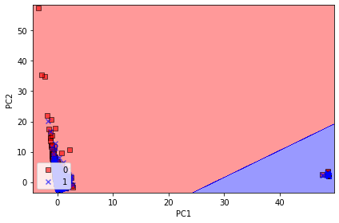

```python
#PCA(주성분 분석)
from sklearn.model_selection import train_test_split
X, y = drop_data.iloc[:, 1:], drop_data.iloc[:, 0].values
X_train, X_test, y_train, y_test = train_test_split(X, y, test_size=0.3,
                                                    stratify=y,
                                                    random_state=0)

#특성을 표준화 전처리
std= StandardScaler()
X_train_scaled = std.fit_transform(X_train)
X_test_scaled = std.transform(X_test)

#PCA
from sklearn.linear_model import LogisticRegression
from sklearn.decomposition import PCA

#PCA 변환기와 로지스틱 회귀 추정기 초기화
pca = PCA(n_components=2)
lr = LogisticRegression(random_state=0)

#차원 축소
X_train_pca = pca.fit_transform(X_train_scaled)
X_test_pca = pca.transform(X_test_scaled)

#축소된 데이터셋으로 로지스틱 회귀모델 훈련
lr.fit(X_train_pca, y_train)
#결정경계 그리기
plot_decision_regions(X_train_pca, y_train, classifier=lr)
plt.xlabel('PC1')
plt.ylabel('PC2')
plt.legend(loc='lower left')
plt.tight_layout()
plt.show()
```

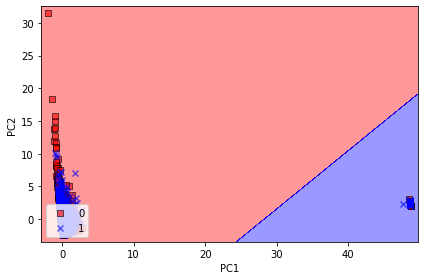

```python
#테스트 데이터셋 기준
plot_decision_regions(X_test_pca, y_test, classifier=lr)
plt.xlabel('PC1')
plt.ylabel('PC2')
plt.legend(loc='lower left')
plt.tight_layout()
plt.show()
```

```python
#주성분 분석을 이용한 분류는 매우 안좋게 나옴
```

```python
#선형판별분석
"""
-데이터셋 표준화
-각 클래스에 대해 d 차원의 평균벡터 계산
-클래스 간의 산포 행렬 Sb와 클래스내 산포행렬 Sw를 구성
-행렬의 고유벡터와 고윳값 계산
-고윳값을 내림차순으로 정렬하여 고유 벡터의 순서를 매김
-고윳값이 가장 큰 k개의 고유벡터를 선택하여 d x k 차원의 변환 행렬 w를 구성..
 이 행렬의 열이 고유벡터
-변환행렬 w를 사용해 샘플을 샐운 특성 부분 공간으로 투영
"""
```

```python
drop_data.columns
```

```
Index(['SeriousDlqin2yrs', 'RevolvingUtilizationOfUnsecuredLines', 'age',
       'NumberOfTime30-59DaysPastDueNotWorse', 'DebtRatio', 'MonthlyIncome',
       'NumberOfOpenCreditLinesAndLoans', 'NumberOfTimes90DaysLate',
       'NumberRealEstateLoansOrLines', 'NumberOfTime60-89DaysPastDueNotWorse',
       'NumberOfDependents'],
      dtype='object')
```

```python
#LDA
from sklearn.discriminant_analysis import LinearDiscriminantAnalysis as LDA

from sklearn.model_selection import train_test_split
X, y = drop_data.iloc[:, 1:], drop_data.iloc[:, 0].values
X_train, X_test, y_train, y_test = train_test_split(X, y, test_size=0.3,
                                                    stratify=y,
                                                    random_state=0)

# 데이터 정규 스케일링
std= StandardScaler()
X_train_scaled = std.fit_transform(X_train)
X_test_scaled = std.transform(X_test)

# n_components로 주성분을 몇개로 할지 결정
lda = LDA(n_components=1)
X_train_lda = lda.fit_transform(X_train_scaled, y_train)

lr = LogisticRegression(random_state=0)
lr = lr.fit(X_train_lda, y_train)
#아래 코드 안됨
plot_decision_regions(X_train_lda, y_train, classifier=lr)

plt.xlabel('LD 1')
plt.ylabel('LD 2')
plt.legend(loc='lower left')
plt.tight_layout()
plt.show()
```

[output not shown]

```python
pd.DataFrame(X_train_lda)
#LDA는 못쓰겠음
```

|  | 0 |
| --- | --- |
| 0 | -0.573178 |
| 1 | 1.004205 |
| 2 | 2.046455 |
| 3 | -0.084336 |
| 4 | -0.857725 |
| ... | ... |
| 84183 | 0.334759 |
| 84184 | 0.011466 |
| 84185 | -0.038593 |
| 84186 | 0.030675 |
| 84187 | 0.421350 |

84188 rows × 1 columns

```python
#LDA 책의 다른버전 못씀

"""from sklearn.discriminant_analysis import LinearDiscriminantAnalysis
from sklearn.preprocessing import StandardScaler
from sklearn.datasets import load_iris
import pandas as pd
import matplotlib.pyplot as plt
#notebook을 실행한 브라우저에서 바로 그림을 볼 수 있게 해주는 것
%matplotlib inline

from sklearn.model_selection import train_test_split
X, y = drop_data.iloc[:, 1:], drop_data.iloc[:, 0].values
X_train, X_test, y_train, y_test = train_test_split(X, y, test_size=0.3,
                                                    stratify=y,
                                                    random_state=0)

# 데이터 정규 스케일링
std= StandardScaler()
X_train_scaled = std.fit_transform(X_train)
X_test_scaled = std.transform(X_test)

# 2개의 클래스로 구분하기 위한 LDA 생성
# n_components로 주성분을 몇개로 할지 결정
lda = LinearDiscriminantAnalysis(n_components=2)

#학습
lda.fit(X_train_scaled, y_train)
lda_train = lda.transform(X_train_scaled)

lr=LogisticRegression(random_state=2)
lr = lr.fit()

# fit()호출 시 target값 입력
#lda.fit(iris_scaled, iris.target)
#iris_lda = lda.transform(iris_scaled)

lda_columns=['lda_component_1','lda_component_2']
lda_df = pd.DataFrame(lda_train, columns=lda_columns)
lda_df['target']=y_train

markers=['^', 's', 'o']
#target 값은 0, 그외는 1~ 각 target 별로 다른 shape으로 scatter plot
for i, marker in enumerate(markers):
    x_axis_data = lda_df[lda_df['target']==i]['lda_component_1']
    y_axis_data = lda_df[lda_df['target']==i]['lda_component_2']

    plt.scatter(x_axis_data, y_axis_data, marker=marker, label=drop_data.columns[i])
                #label=iris.target_names[i])

plt.legend(loc='upper right')
plt.xlabel('lda_component_1')
plt.ylabel('lda_component_2')
plt.show()
"""
print('에러')
```

```
에러
```

```python
#커널 PCA
from sklearn.decomposition import KernelPCA

from sklearn.discriminant_analysis import LinearDiscriminantAnalysis
from sklearn.preprocessing import StandardScaler
from sklearn.datasets import load_iris
import pandas as pd
import matplotlib.pyplot as plt

from sklearn.model_selection import train_test_split
X, y = drop_data.iloc[:, 1:], drop_data.iloc[:, 0].values
X_train, X_test, y_train, y_test = train_test_split(X, y, test_size=0.3,
                                                    stratify=y,
                                                    random_state=0)

# 데이터 정규 스케일링
std= StandardScaler()
X_train_scaled = std.fit_transform(X_train)
X_test_scaled = std.transform(X_test)

scikit_kpca = KernelPCA(n_components=2,
                       kernel='rbf',
                       gamma=15,
                        n_jobs=-1
                       )
X_skernpca = scikit_kpca.fit_transform(X_train_scaled)

plt.scatter(X_skernpca[y==0, 0], X_sklernpca[y==0, 1],
           color = 'red', marker='^', alpha=0.5)
plt.scatter(X_skernpca[y==1, 0], X_sklernpca[y==1, 1],
           color = 'blue', marker='o', alpha=0.5)

plt.xlabel('PC1')
plt.ylabel('PC2')
plt.tight_layout()
plt.show()

#메모리 에러나서 못함
```

[output not shown]

[output cut: 72 more lines]

[output not shown]

```python
#매니폴드 학습
#비선형 차원축소

#그래프 함수
def plot_manifold(X, y):
    plt.scatter(X[y==0, 0], X[y==0, 1],
               color='red', marker='^', alpha=0.5)
    plt.scatter(X[y==1, 0], X[y==1, 1],
               color='blue', marker='o', alpha=0.5)
    plt.xlabel('PC1')
    plt.ylabel('PC2')
    plt.tight_layout()
    plt.show()
```

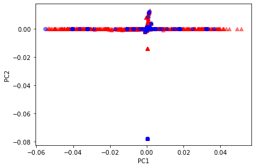

```python
#지역 선형 임베딩
from sklearn.manifold import LocallyLinearEmbedding
lie = LocallyLinearEmbedding(n_components=2, random_state=0, n_jobs=-1)
X_lie=lie.fit_transform(X_train)
plot_manifold(X_lie, y_train)
```

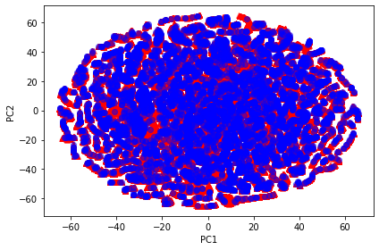

```python
#TSNE
from sklearn.manifold import TSNE
lie = TSNE(n_components=2, random_state=0, n_jobs=-1)
X_lie=lie.fit_transform(X_train)
plot_manifold(X_lie, y_train)
```

```python
#차원축소는 모두 성과가 좋지 못함
```

# 트리 baseline model

```python
import pandas as pd
#data=pd.read_csv('./mini_project/cs_data.csv')
data=pd.read_csv('./cs_data.csv')
#data=pd.read_csv('./Program_Files/mini_project/cs_data.csv')

data.drop(columns='Unnamed: 0', inplace=True)
drop_data=data.dropna()
```

# 레이블 인코딩

- 숫자의 차이가 모델에 영향을 주지 않는 트리 계열 모델(의사결정나무, 랜덤포레스트)에 적용한다.
- 숫자의 차이가 모델에 영향을 미치는 선형 계열 모델(로지스틱회귀, SVM, 신경망)에는 사용하면 안된다.

# 원핫인코딩

- 숫자의 차이가 모델에 영향을 미치는 선형 계열 모델(로지스틱회귀, SVM, 신경망)에서 범주형 데이터 변환시 Label Encoding보다 One Hot Encoding을 사용한다.
- DecisionTree 계열의 알고리즘은 Feature에 0이 많은 경우(Sparse Matrix라고 한다.) 성능이 떨어지기 때문에 Label Encoding을 한다.

선형모델(로지스틱 회귀, svm, 신경망) -원핫인코딩

비선형모델(트리계열 알고리즘) -레이블인코딩

## 레이블인코딩

```python
#레이블인코딩(트리모델)
from sklearn.preprocessing import LabelEncoder
import numpy as np
import pandas as np

#현재 데이터 기준 굳이 하지 않았어도 되어보임
items= list(np.unique(drop_data['SeriousDlqin2yrs']))
le = LabelEncoder()
le.fit(drop_data['SeriousDlqin2yrs'])
labels=le.transform(drop_data['SeriousDlqin2yrs'])
labels
```

```
array([1, 0, 0, ..., 0, 0, 0], dtype=int64)
```

```python
le.classes_
le.inverse_transform(drop_data['SeriousDlqin2yrs'])
```

```
array([1, 0, 0, ..., 0, 0, 0], dtype=int64)
```

```python
#이번 데이터는 모든 컬럼에 범주형 데이터가 존재하지 않음
```

```python
from sklearn.tree import DecisionTreeClassifier
from sklearn.model_selection import train_test_split
from sklearn.metrics import accuracy_score

df = DecisionTreeClassifier()
df.fit(X_train, y_train)
pred_X_train=df.predict(X_train)
pred_X_test=df.predict(X_test)
pred_val= df.predict(X_val)

from sklearn.metrics import accuracy_score
print('train',accuracy_score(y_train, pred_X_train))
print('val', accuracy_score(y_val, pred_val))
print('test', accuracy_score(y_test, pred_X_test))
```

[output not shown]

## 의사결정나무

### holdout

```python
from sklearn.model_selection import train_test_split
from sklearn.tree import DecisionTreeClassifier
from sklearn.metrics import accuracy_score
import numpy as np

#X, y = drop_data.iloc[:, 1:], drop_data.iloc[:, 0].values

#y = drop_data['SeriousDlqin2yrs'].to_numpy()
#X = drop_data.drop('SeriousDlqin2yrs', axis=1).to_numpy()

X,y = drop_data.iloc[:,1:], drop_data.iloc[:,0].to_numpy()

#train/validation/test set 분리
X_train, X_test, y_train, y_test = train_test_split(X,
                                                   y,
                                                   test_size=0.2,
                                                   random_state=0,
                                                   stratify=y)

#validation set을 만들땐 stratify넣으면 안됨
X_train, X_val, y_train, y_val = train_test_split(X_train,
                                                  y_train,
                                                  stratify=y_train,
                                                  random_state=0)

tree_clf = DecisionTreeClassifier(random_state=0)
tree_clf.fit(X_train, y_train)

train_pred = tree_clf.predict(X_train)
val_pred = tree_clf.predict(X_val)
test_pred = tree_clf.predict(X_test)

acc_train = accuracy_score(y_train, train_pred)
acc_val = accuracy_score(y_val, val_pred)
acc_test = accuracy_score(y_test, test_pred)

print(acc_train, acc_val, acc_test)

#roc_auc_score
from sklearn.metrics import roc_auc_score
tree_train_pos = tree_clf.predict_proba(X_train)[:,1]
tree_test_pos = tree_clf.predict_proba(X_test)[:,1]

print('###################################################')
print(roc_auc_score(y_train, tree_train_pos))
print(roc_auc_score(y_test, tree_test_pos))
```

```
0.9999722841978353 0.8912862725534215 0.8948615614866551
###################################################
0.9999999910893309
0.610952924353523
```

### StratifiedKFold

```python
#k-fold cross validation
#데이터양이 충분치 않을때 사용
"""
KFold
- 회귀문제의 Dataset을 분리할 때 사용
StratifiedKFold
- 분류분제의 Dataset을 분리할 때 사용
"""
print('')
```

```python
from sklearn.model_selection import StratifiedKFold
#옵션 n_splits
sfold= StratifiedKFold(n_splits=3)

#회귀문제에 사용된 kfold는 x만 split하는 것과 달리
#stratiedkfold는 x와 y를 split 하도록 한다.
#ex = sfold.split(X, y)

y = drop_data['SeriousDlqin2yrs'].to_numpy()
X = drop_data.drop('SeriousDlqin2yrs', axis=1).to_numpy()

acc_train_list = []
acc_test_list =[]

#데이터가 Dataframe형식이면 안됨 반드시 numpy array 형식이어야 함
#각 폴드의 결과를 저장할 리스트 생성
acc_train_list = []
acc_test_list = []

for train_index, test_index in sfold.split(X, y):
    #기존에 train_test_split과는 다르게
    #fold에서는 train별 test별로 데이터를 받음
    X_train, y_train = X[train_index], y[train_index]
    X_test, y_test = X[test_index], y[test_index]

    #모델 생성
    tree_clf = DecisionTreeClassifier()

    #학습
    tree_clf.fit(X_train, y_train)

    #검증
    pred_train = tree_clf.predict(X_train)
    pred_test = tree_clf.predict(X_test)

    #평가
    acc_train = accuracy_score(y_train, pred_train)
    acc_test = accuracy_score(y_test, pred_test)

    acc_train_list.append(acc_train)
    acc_test_list.append(acc_test)

import pandas as pd
import numpy as np

print('train', acc_train_list, np.mean(acc_train_list))
print('test', acc_test_list, np.mean(acc_test_list))

##roc_auc

tree_train_pos = tree_clf.predict_proba(X_train)[:,1]
tree_test_pos = tree_clf.predict_proba(X_test)[:,1]

print('###################################################')
print(roc_auc_score(y_train, tree_train_pos))
print(roc_auc_score(y_test, tree_test_pos))
```

```
train [0.9999875279063096, 0.9999750558126193, 1.0] 0.9999875279063096
test [0.8906709902718882, 0.8905462708904964, 0.8924642670059119] 0.8912271760560988
###################################################
1.0
0.6071341351431163
```

## randomforest

### holdout

```python
from sklearn.model_selection import train_test_split
from sklearn.ensemble import RandomForestClassifier
from sklearn.metrics import accuracy_score
import numpy as np

y = drop_data['SeriousDlqin2yrs'].to_numpy()
X = drop_data.drop('SeriousDlqin2yrs', axis=1).to_numpy()

from sklearn.model_selection import train_test_split
X_train, X_test, y_train, y_test = train_test_split(X, y, stratify=y, random_state=0, test_size=0.2)
X_train, X_val, y_train, y_val = train_test_split(X_train, y_train, stratify=y_train, random_state=0)

rf = RandomForestClassifier(random_state=0)
rf.fit(X_train, y_train)

train_pred = rf.predict(X_train)
val_pred = rf.predict(X_val)
test_pred = rf.predict(X_test)

acc_train = accuracy_score(y_train, train_pred)
acc_val = accuracy_score(y_val, val_pred)
acc_test = accuracy_score(y_test, test_pred)

print(acc_train, acc_val, acc_test)

##roc_auc

rf_train_pos = rf.predict_proba(X_train)[:,1]
rf_test_pos = rf.predict_proba(X_test)[:,1]

print('###################################################')
print(roc_auc_score(y_train, rf_train_pos))
print(roc_auc_score(y_test, rf_test_pos))
```

```
0.9999307104945885 0.9324020952856074 0.9341065934979629
###################################################
0.9999976297620479
0.8272479356915552
```

### StrafifiedKFold

```python
from sklearn.ensemble import RandomForestClassifier
from sklearn.model_selection import StratifiedKFold
from sklearn.metrics import accuracy_score
import numpy as np

sfold=StratifiedKFold(n_splits=3)
#ex=sfold.split(X,y)

y = drop_data['SeriousDlqin2yrs'].to_numpy()
X = drop_data.drop('SeriousDlqin2yrs', axis=1).to_numpy()

acc_train_list=[]
acc_test_list=[]

for train_index, test_index in sfold.split(X,y):
    X_train, y_train = X[train_index], y[train_index]
    X_test, y_test = X[test_index], y[test_index]

    rf = RandomForestClassifier(random_state=0)

    rf.fit(X_train, y_train)

    pred_train = rf.predict(X_train)
    pred_test = rf.predict(X_test)

    acc_train = accuracy_score(y_train, pred_train)
    acc_test = accuracy_score(y_test, pred_test)

    acc_train_list.append(acc_train)
    acc_test_list.append(acc_test)

print('train', acc_train_list, np.mean(acc_train_list))
print('test', acc_test_list, np.mean(acc_test_list))

##roc_auc

rf_train_pos = rf.predict_proba(X_train)[:,1]
rf_test_pos = rf.predict_proba(X_test)[:,1]

print('###################################################')
print(roc_auc_score(y_train, rf_train_pos))
print(roc_auc_score(y_test, rf_test_pos))
```

```
train [0.9999376395315481, 0.9998877511567867, 0.9999501122474432] 0.9999251676452593
test [0.932776253429783, 0.933374906460464, 0.9326249095761929] 0.9329253564888133
###################################################
1.0
0.8331662778641284
```

```python
#랜덤 포래스트는 튜닝하면 쓸만할 듯
```

## GradientBoostingClassifier

### holdout

```python
from sklearn.model_selection import train_test_split
from sklearn.ensemble import GradientBoostingClassifier
from sklearn.metrics import accuracy_score
import numpy as np

y = drop_data['SeriousDlqin2yrs'].to_numpy()
X = drop_data.drop('SeriousDlqin2yrs', axis=1).to_numpy()

from sklearn.model_selection import train_test_split
X_train, X_test, y_train, y_test = train_test_split(X, y, stratify=y, random_state=0, test_size=0.2)
X_train, X_val, y_train, y_val = train_test_split(X_train, y_train, stratify=y_train, random_state=0)

gb = GradientBoostingClassifier(random_state=0)
gb.fit(X_train, y_train)

train_pred = gb.predict(X_train)
val_pred = gb.predict(X_val)
test_pred = gb.predict(X_test)

acc_train = accuracy_score(y_train, train_pred)
acc_val = accuracy_score(y_val, val_pred)
acc_test = accuracy_score(y_test, test_pred)

print(acc_train, acc_val, acc_test)

##roc_auc

gb_train_pos = gb.predict_proba(X_train)[:,1]
gb_test_pos = gb.predict_proba(X_test)[:,1]

print('###################################################')
print(roc_auc_score(y_train, gb_train_pos))
print(roc_auc_score(y_test, gb_test_pos))
```

```
0.9369742658776902 0.932776253429783 0.9356863723289266
###################################################
0.8595502417645681
0.8546685466734354
```

### StratifiedKFold

```python
from sklearn.ensemble import GradientBoostingClassifier
from sklearn.model_selection import StratifiedKFold
from sklearn.metrics import accuracy_score
import numpy as np

sfold=StratifiedKFold(n_splits=3)
#ex=sfold.split(X,y)

y = drop_data['SeriousDlqin2yrs'].to_numpy()
X = drop_data.drop('SeriousDlqin2yrs', axis=1).to_numpy()

acc_train_list=[]
acc_test_list=[]

for train_index, test_index in sfold.split(X,y):
    X_train, y_train = X[train_index], y[train_index]
    X_test, y_test = X[test_index], y[test_index]

    gr = GradientBoostingClassifier(random_state=0)

    gr.fit(X_train, y_train)

    pred_train = gr.predict(X_train)
    pred_test = gr.predict(X_test)

    acc_train = accuracy_score(y_train, pred_train)
    acc_test = accuracy_score(y_test, pred_test)

    acc_train_list.append(acc_train)
    acc_test_list.append(acc_test)

print('train', acc_train_list, np.mean(acc_train_list))
print('test', acc_test_list, np.mean(acc_test_list))

##roc_auc

gr_train_pos = gr.predict_proba(X_train)[:,1]
gr_test_pos = gr.predict_proba(X_test)[:,1]

print('###################################################')
print(roc_auc_score(y_train, gr_train_pos))
print(roc_auc_score(y_test, gr_test_pos))
```

```
train [0.9370408710510233, 0.936554459397099, 0.9364804190571214] 0.936691916501748
test [0.9348216512846096, 0.934247942130207, 0.9341215794856444] 0.934397057633487
###################################################
0.8617758326304171
0.8567573098278168
```

```python
#GradientBoostingClassifier는 기본적으로 85퍼센트를 넘김 사용하기에 좋아보임
```